[figure not shown]

# Preliminary Modeling of CMS Medicare Physican Data

I am revisiting the Center for Medicare and Medicaid Services (CMS) data that I analyzed previously in Spark. Each instance of this dataset is the annual aggregate data for a physician who charged Medicare for the year 2016. I want to perform data cleaning and preliminary modeling of the data as I prepare to build a regressor neural network to predict Total Medicare Payouts to healthcare providers.

Medicare is estimated to provide health insurance to over 60 million Americans, most of who are over the age of 65. Roughly 14% of the federal budget in FY18 was spent on Medicare, which amounts to approximately USD 582 billion. This is equivalent to approximately 3% of national GDP. The federal budget passed earlier this year proposes to cut Medicare by USD 451 billion over the next 10 years. Revenue loss from Medicare cuts will affect sectors geographies of the healthcare industry in different ways.

My Spark analysis indicated that 948,189 practices, spread across 90 different practice types, charged Medicare in 2016. Internal medicine practices received the highest total annual payout from Medicare, with a total of USD 6.68 billion. The max annual payout any single practice received was USD 208 million by a clinical laboratory. Additionally, clinical laboratories received the highest average annual payout among all practice types (USD 1.61 million), however, that is distorted by the single max payout mentioned above and further proves the point of how much of an outlier that data point may be. Radiation therapy centers were second in average annual payout at USD 1.18 million with a considerably modest max annual payout of USD 7,248,542.

Link to the data: https://www.kaggle.com/cms/medicare-physician-other-supplier-npi-aggregates#medicare-physician-and-other-supplier-national-provider-identifier-npi-aggregate-report-calendar-year-2016.csv

```python
import numpy as np
import pandas as pd
import matplotlib.pyplot as plt
import datetime
import warnings
```

```python
from sklearn.preprocessing import MinMaxScaler
from sklearn.model_selection import train_test_split
from sklearn.linear_model import LinearRegression
from sklearn import linear_model
from keras.utils import to_categorical

warnings.filterwarnings('ignore')
```

### Read in Data

I read the CSV file into a pandas dataframe and call a description. The dataset is pretty large with 1,048,575 instances and 54 variables. I already deleted some columns while cleaning the data in Excel, as well. I've also called a list of the variables that are present in the dataset.

```python
df = pd.read_csv('medicare_clean.csv')
df.shape
```

```
(1048575, 54)
```

```python
df.columns
```

```
Index(['Credentials of the Provider', 'Gender of the Provider',
       'City of the Provider', 'State Code of the Provider',
       'Provider Type of the Provider', 'Number of HCPCS',
       'Number of Services', 'Number of Medicare Beneficiaries',
       'Total Submitted Charge Amount', 'Total Medicare Allowed Amount',
       'Total Medicare Payment Amount',
       'Number of HCPCS Associated With Drug Services',
       'Number of Drug Services',
       'Number of Medicare Beneficiaries With Drug Services',
       'Total Drug Submitted Charge Amount',
       'Total Drug Medicare Allowed Amount',
       'Total Drug Medicare Payment Amount',
       'Number of HCPCS Associated With Medical Services',
       'Number of Medical Services', 'Total Medical Submitted Charge Amount',
       'Total Medical Medicare Allowed Amount',
       'Total Medical Medicare Payment Amount', 'Average Age of Beneficiaries',
       'Number of Beneficiaries Age Less 65',
       'Number of Beneficiaries Age 65 to 74',
       'Number of Beneficiaries Age 75 to 84',
       'Number of Beneficiaries Age Greater 84',
       'Number of Female Beneficiaries', 'Number of Male Beneficiaries\t',
       'Number of Non-Hispanic White Beneficiaries\t',
       'Number of Black or African American Beneficiaries',
       'Number of Asian Pacific Islander Beneficiaries',
       'Number of Hispanic Beneficiaries',
       'Number of American Indian/Alaska Native Beneficiaries',
       'Number of Beneficiaries With Race Not Elsewhere Classified',
       'Number of Beneficiaries With Medicare Only Entitlement',
       'Number of Beneficiaries With Medicare & Medicaid Entitlement',
       'Percent (%) of Beneficiaries Identified With Atrial Fibrillation',
       'Percent (%) of Beneficiaries Identified With Alzheimer’s Disease or Dementia',
       'Percent (%) of Beneficiaries Identified With Asthma',
       'Percent (%) of Beneficiaries Identified With Cancer',
       'Percent (%) of Beneficiaries Identified With Heart Failure',
       'Percent (%) of Beneficiaries Identified With Chronic Kidney Disease',
       'Percent (%) of Beneficiaries Identified With Chronic Obstructive Pulmonary Disease',
       'Percent (%) of Beneficiaries Identified With Depression',
       'Percent (%) of Beneficiaries Identified With Diabetes',
       'Percent (%) of Beneficiaries Identified With Hyperlipidemia',
       'Percent (%) of Beneficiaries Identified With Hypertension',
       'Percent (%) of Beneficiaries Identified With Ischemic Heart Disease',
       'Percent (%) of Beneficiaries Identified With Osteoporosis',
       'Percent (%) of Beneficiaries Identified With Rheumatoid Arthritis / Osteoarthritis',
       'Percent (%) of Beneficiaries Identified With Schizophrenia / Other Psychotic Disorders',
       'Percent (%) of Beneficiaries Identified With Stroke',
       'Average HCC Risk Score of Beneficiaries'],
      dtype='object')
```

### Quick EDA

I wanted to perform some quick EDA before I started cleaning the data and likely lose many instances.

The states with the largest number of healthcare providers who requested payment from Medicare are in California, Florida, Illinois, New York, Ohio, Pennsylvania, and Texas. The largest number of healthcare providers who requested payment from Medicare are CRNAs, emergency medicine practitioners, family practices,internal medicine, nurse practitioners, PTs, and PAs.

```python
by_state = df.groupby('State Code of the Provider')['State Code of the Provider'].agg('count')
high = by_state[by_state > 40000]
high
```

```
State Code of the Provider
CA    84986
FL    63744
IL    43050
NY    73592
OH    42097
PA    53041
TX    66261
Name: State Code of the Provider, dtype: int64
```

```python
by_provider = df.groupby('Provider Type of the Provider')['Provider Type of the Provider'].agg('count')
high = by_provider[by_provider > 40000]
high
```

```
Provider Type of the Provider
Certified Registered Nurse Anesthetist (CRNA)     41811
Emergency Medicine                                42363
Family Practice                                   83702
Internal Medicine                                100296
Nurse Practitioner                                98002
Physical Therapist in Private Practice            46965
Physician Assistant                               65613
Name: Provider Type of the Provider, dtype: int64
```

### Missing values

After examining the dataset in Excel, I realized that there are a lot of missing values for numerous variables. Because my background in healthcare is limited, I will not assume any methodology for imputation but will remove any instance where a variable is Null.

```python
df.isnull().sum()
```

```
Credentials of the Provider                                                               103145
Gender of the Provider                                                                     62298
City of the Provider                                                                           1
State Code of the Provider                                                                     0
Provider Type of the Provider                                                                  0
Number of HCPCS                                                                                0
Number of Services                                                                             0
Number of Medicare Beneficiaries                                                               0
Total Submitted Charge Amount                                                                  0
Total Medicare Allowed Amount                                                                  0
Total Medicare Payment Amount                                                                  0
Number of HCPCS Associated With Drug Services                                             108825
Number of Drug Services                                                                   108825
Number of Medicare Beneficiaries With Drug Services                                       108825
Total Drug Submitted Charge Amount                                                        108825
Total Drug Medicare Allowed Amount                                                        108825
Total Drug Medicare Payment Amount                                                        108825
Number of HCPCS Associated With Medical Services                                          108825
Number of Medical Services                                                                108825
Total Medical Submitted Charge Amount                                                     108825
Total Medical Medicare Allowed Amount                                                     108825
Total Medical Medicare Payment Amount                                                     108825
Average Age of Beneficiaries                                                                   0
Number of Beneficiaries Age Less 65                                                       358148
Number of Beneficiaries Age 65 to 74                                                      164750
Number of Beneficiaries Age 75 to 84                                                      300279
Number of Beneficiaries Age Greater 84                                                    423464
Number of Female Beneficiaries                                                            114205
Number of Male Beneficiaries\t                                                            114205
Number of Non-Hispanic White Beneficiaries\t                                              343038
Number of Black or African American Beneficiaries                                         688046
Number of Asian Pacific Islander Beneficiaries                                            863561
Number of Hispanic Beneficiaries                                                          767896
Number of American Indian/Alaska Native Beneficiaries                                     736392
Number of Beneficiaries With Race Not Elsewhere Classified                                887091
Number of Beneficiaries With Medicare Only Entitlement                                    260470
Number of Beneficiaries With Medicare & Medicaid Entitlement                              260470
Percent (%) of Beneficiaries Identified With Atrial Fibrillation                          338717
Percent (%) of Beneficiaries Identified With Alzheimer’s Disease or Dementia              344622
Percent (%) of Beneficiaries Identified With Asthma                                       237693
Percent (%) of Beneficiaries Identified With Cancer                                       345289
Percent (%) of Beneficiaries Identified With Heart Failure                                263531
Percent (%) of Beneficiaries Identified With Chronic Kidney Disease                       173351
Percent (%) of Beneficiaries Identified With Chronic Obstructive Pulmonary Disease        280240
Percent (%) of Beneficiaries Identified With Depression                                   165697
Percent (%) of Beneficiaries Identified With Diabetes                                     148365
Percent (%) of Beneficiaries Identified With Hyperlipidemia                                81311
Percent (%) of Beneficiaries Identified With Hypertension                                  55010
Percent (%) of Beneficiaries Identified With Ischemic Heart Disease                       157242
Percent (%) of Beneficiaries Identified With Osteoporosis                                 395779
Percent (%) of Beneficiaries Identified With Rheumatoid Arthritis / Osteoarthritis        100708
Percent (%) of Beneficiaries Identified With Schizophrenia / Other Psychotic Disorders    544280
Percent (%) of Beneficiaries Identified With Stroke                                       474494
Average HCC Risk Score of Beneficiaries                                                        0
dtype: int64
```

```python
df2 = df.drop(['Number of Beneficiaries Age Greater 84','Number of Non-Hispanic White Beneficiaries\t','Number of Black or African American Beneficiaries',
              'Number of Asian Pacific Islander Beneficiaries','Number of Hispanic Beneficiaries',
             'Number of American Indian/Alaska Native Beneficiaries','Number of Beneficiaries With Race Not Elsewhere Classified',
             'Percent (%) of Beneficiaries Identified With Schizophrenia / Other Psychotic Disorders','Percent (%) of Beneficiaries Identified With Stroke',
              'Total Medical Submitted Charge Amount','Total Medical Medicare Allowed Amount','Total Medical Medicare Payment Amount',
              'Total Drug Submitted Charge Amount','Total Drug Medicare Allowed Amount','Total Drug Medicare Payment Amount'],
             axis = 1)
df2.shape
```

```
(1048575, 39)
```

```python
df2 = df2.dropna()
df2.shape
```

```
(398962, 39)
```

```python
#df2.isnull().sum()
```

### Rename columns for easier use in Pandas

The column headings that the data was read in with are not conducive to some of the functional programming features available through Pandas, so I have decided to rename all variables.

```python
df3 = df2.rename(columns={"Credentials of the Provider": "Credential", "Gender of the Provider": "Gender",
                          "City of the Provider":"City","State Code of the Provider":"State",
                          "Provider Type of the Provider":"ProviderType","Number of HCPCS":"Num_HCPCS_Clients",
                          "Number of Services":"Num_Services","Number of Medicare Beneficiaries":"Num_Medicare_Beneficiaries",
                          "Total Submitted Charge Amount":"Total_Submitted_Charge",
                          "Total Medicare Allowed Amount":"Total_Medicare_Allowed",
                          "Total Medicare Payment Amount":"Total_Medicare_Payout",
                          "Number of HCPCS Associated With Drug Services":'Num_HCPCS_DrugServices',
                          "Number of Drug Services":"Num_DrugServices",
                          "Number of Medicare Beneficiaries With Drug Services":"Num_Bens_DrugServices",
                          "Number of HCPCS Associated With Medical Services":"Num_HCPCS_MedicalServices",
                          "Number of Medical Services":"Num_MedicalServices",
                          "Average Age of Beneficiaries":"Avg_Age_Beneficiaries",
                          "Number of Beneficiaries Age Less 65":"Num_Beneficiaries_U65",
                          "Number of Beneficiaries Age 65 to 74":"Num_Beneficiaries_65to74",
                          "Number of Beneficiaries Age 75 to 84":"Num_Beneficiaries_75to84",
                          "Number of Female Beneficiaries":"Num_Beneficiaries_F",
                          "Number of Male Beneficiaries\t":"Num_Beneficiaries_M",
                          "Number of Beneficiaries With Medicare Only Entitlement":"Num_Beneficiaries_Medicare_EntitlementOnly",
                          "Number of Beneficiaries With Medicare & Medicaid Entitlement":"Num_Beneficiaries_MedicareMedicaid_Entitlement",
                          "Percent (%) of Beneficiaries Identified With Atrial Fibrillation":"Perc_Bens_Afib",
                          "Percent (%) of Beneficiaries Identified With Alzheimer’s Disease or Dementia":"Perc_Bens_ALZ",
                          "Percent (%) of Beneficiaries Identified With Asthma":"Perc_Bens_Asthma",
                          "Percent (%) of Beneficiaries Identified With Cancer":"Perc_Bens_Cancer",
                          "Percent (%) of Beneficiaries Identified With Heart Failure":"Perc_Bens_HeartFailure",
                          "Percent (%) of Beneficiaries Identified With Chronic Kidney Disease":"Perc_Bens_KidneyDis",
                          "Percent (%) of Beneficiaries Identified With Chronic Obstructive Pulmonary Disease":"Perc_Bens_PulmDis",
                          "Percent (%) of Beneficiaries Identified With Depression":"Perc_Bens_Depression",
                          "Percent (%) of Beneficiaries Identified With Diabetes":"Perc_Bens_Diabetes",
                          "Percent (%) of Beneficiaries Identified With Hyperlipidemia":"Perc_Bens_Hyperlipidemia",
                          "Percent (%) of Beneficiaries Identified With Hypertension":"Perc_Bens_Hypertension",
                          "Percent (%) of Beneficiaries Identified With Ischemic Heart Disease":"Perc_Bens_IschemicHD",
                          "Percent (%) of Beneficiaries Identified With Osteoporosis":"Perc_Bens_Osteoporosis",
                          "Percent (%) of Beneficiaries Identified With Rheumatoid Arthritis / Osteoarthritis":"Perc_Bens_Arthritis",
                          "Average HCC Risk Score of Beneficiaries":"Avg_HCC_RiskScore"})
```

### Distribution of Dependent Variable

The range in outputs is very wide in Total Medicare Payout; the distribution is exponential. I will take the log of these values to give the variable a normal distribution, which is a preferred assumption when performing linear regression.

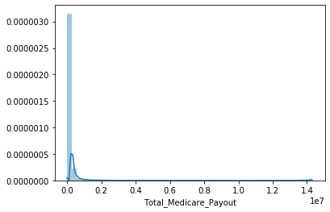

```python
import seaborn as sns

sns.distplot(df3['Total_Medicare_Payout'])
```

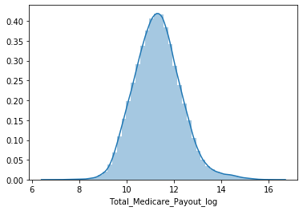

```python
df3['Total_Medicare_Payout_log'] = np.log(df3['Total_Medicare_Payout'])
sns.distplot(df3['Total_Medicare_Payout_log'])
```

### Cleaning up the Credential variable

```python
df3['Credential'] = df3['Credential'].str.replace('.', '')
df3['Credential'] = df3['Credential'].apply(lambda x: x.split(",")[0])

counts = df3['Credential'].value_counts()
df3 = df3[~df3['Credential'].isin(counts[counts < 100].index)]
print(len(df3['Credential'].unique()))
print(df3['Credential'].unique())
df3.shape
```

```
48
['MD' 'DO' 'PA-C' 'ARNP' 'PA' 'PT' 'NP' 'FNP-C' 'DPM' 'OD' 'NP-C' 'DPT'
 'FNP' 'MS' 'CRNA' 'MBBS' 'RN' 'AA' 'CFNP' 'CNP' 'ACNP-BC' 'APRN' 'AUD'
 'FNP-BC' 'MD PHD' 'CRNP' 'PHD' 'MSN' 'PAC' 'NURSE PRACTITIONER' 'ANP'
 'M D' 'MA' 'CNS' 'PSYD' 'ANP-BC' 'APN' 'ACNP' 'DNP' 'APNP' 'RPA-C'
 'MD MPH' 'DC' 'MPT' 'PA C' 'AA-C' 'PHYSICIAN ASSISTANT' 'MD PA']
```

```
(393252, 40)
```

### Cleaning up the State variable

I dropped rows with state values equal to 'XX', 'ZZ', and 'AA' as these do not exist. I also dropped the City variable after considering how it would affect dimensionality through binary encoding.

```python
df4 = df3[df3.State != 'XX']
df4 = df4[df4.State != 'ZZ']
df4 = df4[df4.State != 'AA']
df4 = df4.drop(['City'], axis=1)
pre_outlier = df4.shape[0]
```

### Correlation

I want to explore feature correlation with Medicare Total Payout and the log of Medicare Total Payout. For example, I have variables related to payment including "Total Submitted Charge" and "Total Medicare Allowed" which are likely very correlated with Medicare Total Payout. It would be worthwhile to remove these variables to reduce redundancy if that were the case. Additionally, we can glean some information about the relationship of some variables with the output variable. I will use Pearson's correlation coefficient which searches for a linear relationship between variables.

```python
corrs = df4.corr()
Y_corrs = abs(corrs['Total_Medicare_Payout'])
Y_corrs[Y_corrs > 0.5]
```

```
Num_Services                 0.704781
Total_Submitted_Charge       0.877976
Total_Medicare_Allowed       0.999429
Total_Medicare_Payout        1.000000
Num_HCPCS_DrugServices       0.539902
Num_DrugServices             0.651754
Num_MedicalServices          0.541134
Total_Medicare_Payout_log    0.661395
Name: Total_Medicare_Payout, dtype: float64
```

```python
Y_log_corrs = abs(corrs['Total_Medicare_Payout_log'])
Y_log_corrs[Y_log_corrs > 0.5]
```

```
Total_Submitted_Charge       0.602181
Total_Medicare_Allowed       0.667306
Total_Medicare_Payout        0.661395
Num_MedicalServices          0.527832
Total_Medicare_Payout_log    1.000000
Name: Total_Medicare_Payout_log, dtype: float64
```

'Number of Services', 'Total Submitted Charge', 'Total Medicare Allowed', Number of HCPCS Druge Services', 'Number of Drug Services', and 'Number of Medical Services' all have a correlation greater than 0.5 to Total Medicare Payout before the log transformation. My suspicion about 'Total Submitted Charges' and 'Total Medicare Allowed' was confirmed, as they both have high correlation coefficients. I will remove these variables to reduce dimensionality and redundancy in the data, even if correlation is reduced by taking the log of the true dependent variable. I will also drop the non-log transormed variable now.

```python
df4 = df4.drop(['Total_Submitted_Charge','Total_Medicare_Allowed','Total_Medicare_Payout'], axis=1)
df4.shape
```

```
(393215, 36)
```

### Binary Encoding

The BinaryEncoder() function automatically detects categorical variables and converts them while also removing the previous variables that have been transformed. After binary encoding the four categorical variables in the dataset, there are still only 56 variables.

```python
import category_encoders as ce
from sklearn.preprocessing import LabelEncoder

df4['Credential'] = pd.Categorical(df4['Credential'])
df4['Gender'] = pd.Categorical(df4['Gender'])
df4['State'] = pd.Categorical(df4['State'])
df4['ProviderType'] = pd.Categorical(df4['ProviderType'])

ce_bin = ce.BinaryEncoder()

data = ce_bin.fit_transform(df4)

#ce_bin.get_feature_names()

data.head()

data.shape
```

```
(393215, 56)
```

```python
df_final = data.reset_index(drop=True)
df_final.to_csv('medicare.csv', index=False)
```

```python
cols = data.columns
```

## Data pretreatment

In this model, total annual medicare payout is the dependent variable that my model is training to predict. I separate this column from my dataframe using the pop() function and scale the numerical X's. Scaling reduces the range of values in a column to 0 to 1. This reduces the stretch that occurs in model dimensionality as numerous varibales are read in. Finally, I turn my X and Y dataframe into a Numpy array, which is the preferred data structure to feed to ML models. The data is now ready to be sent through the model. The data will be split into training and test data with the train_test_split() functino from SK-Learn.

```python
from sklearn.model_selection import train_test_split

cols = list(data.columns.values)
Y_name = cols.pop(cols.index('Total_Medicare_Payout_log'))

Y = data[Y_name]
Y=Y.astype('float')
X = data.drop([Y_name], axis=1)
#print(X.columns.values)

scaler = MinMaxScaler()
X.iloc[:,24:55] = scaler.fit_transform(X.iloc[:,24:55])

X_array = X.to_numpy()
Y_array = Y.to_numpy()

X_train, X_test, y_train, y_test = train_test_split(X_array, Y_array, test_size=0.25, random_state=42)
```

## Preliminary Modeling

### Lasso Regression

Performing a lasso regression will help me understand feature importance. By setting the alpha (penalty term) at a reasonable value, we will produce a model that is moderately critical of features that have little predictive power. Surprisingly, 35 out of 55 features are lassoed when alpha = 0.01. There are both categorical and numerical variables lassoed which may or may not produce better results. At this point, however, I will not drop these features but move ahead with what I have.

```python
clf = linear_model.Lasso(alpha=0.01)
lasso_mod = clf.fit(X,Y)
print(lasso_mod.coef_)

#warnings.filterwarnings('ignore')
```

```
[ 0.00000000e+00  0.00000000e+00  7.07185837e-01  0.00000000e+00
  0.00000000e+00 -1.43352147e-02 -1.04119566e-01  2.91852620e-01
 -1.02256993e-15  0.00000000e+00 -3.93095662e-02 -2.45427230e-02
 -8.25137494e-03  9.63917841e-03 -3.78868472e-02  0.00000000e+00
  0.00000000e+00  3.74321760e-01  1.81687083e-01  0.00000000e+00
 -0.00000000e+00  0.00000000e+00 -7.12402455e-02 -2.67188661e-01
  1.38820875e+00  0.00000000e+00  0.00000000e+00  2.33054005e+00
  0.00000000e+00  0.00000000e+00  0.00000000e+00  0.00000000e+00
  8.69494811e-01  0.00000000e+00  0.00000000e+00  0.00000000e+00
  0.00000000e+00  0.00000000e+00  0.00000000e+00  0.00000000e+00
 -0.00000000e+00  0.00000000e+00 -0.00000000e+00 -0.00000000e+00
  0.00000000e+00 -0.00000000e+00 -0.00000000e+00 -2.16749237e-01
  0.00000000e+00  2.56575006e-01  0.00000000e+00  7.02816642e-02
 -0.00000000e+00  0.00000000e+00  0.00000000e+00]
```

Thefeatures below were not lassoed, meaning they may have more importance in predicting the dependent variable.

```python
zero_ind = np.argwhere(lasso_mod.coef_ == 0)
```

```python
coeffs = lasso_mod.coef_
zeros = np.argwhere(coeffs != 0)
for i in np.nditer(zeros):
    print(cols[i])
```

```
Credential_2
Credential_5
Credential_6
Gender_0
Gender_1
State_1
State_2
State_3
State_4
State_5
ProviderType_1
ProviderType_2
ProviderType_6
ProviderType_7
Num_HCPCS_Clients
Num_HCPCS_DrugServices
Avg_Age_Beneficiaries
Perc_Bens_Depression
Perc_Bens_Hyperlipidemia
Perc_Bens_IschemicHD
```

### K Best Subset Feature Selection

Next, I explore feature selection a little bit more to understand what group of variables perform best at predicting Total Medicare Payout. I arbitrarily chose a subset of size k = 10. The SelectKBest() function will choose the ten features that create the best model. I used the F-statistics as the scoring funciton.

```python
from numpy import set_printoptions
from sklearn.feature_selection import SelectKBest
from sklearn.feature_selection import f_classif


# feature extraction
test = SelectKBest(score_func=f_classif, k=10)
fit = test.fit(X, Y)

# summarize scores
set_printoptions(precision=3)
print(fit.scores_)

#features = fit.transform(X)
warnings.filterwarnings('ignore')
```

```
[   nan  0.815  0.941  0.916  0.949  0.928  0.945  0.935  0.935    nan
  0.977  0.982  0.991  0.981  1.004  0.978    nan  1.742  1.026  0.992
  1.026  1.033  1.012  1.122  1.831 89.292  3.185  4.324 94.104  3.754
  1.745 18.821  1.032  2.037  3.562  3.659  3.132  3.287  3.69   2.056
  1.047  1.04   1.121  1.364  1.07   1.064  1.112  1.066  1.117  1.019
  0.958  1.072  1.116  1.124  1.18 ]
```

Ironically, some of the highest scoring variables were lassoed in the lasso regression.

```python
feats = fit.get_support(indices=True)

for i in feats:
    print(cols[i]," - ",fit.scores_[i])
```

```
Num_Services  -  89.29189880085318
Num_Medicare_Beneficiaries  -  3.1852225574700013
Num_HCPCS_DrugServices  -  4.3240171224671045
Num_DrugServices  -  94.10449669399038
Num_Bens_DrugServices  -  3.754479299755721
Num_MedicalServices  -  18.82139770874719
Num_Beneficiaries_65to74  -  3.5615968780668306
Num_Beneficiaries_75to84  -  3.6586072464399555
Num_Beneficiaries_M  -  3.2870637337697075
Num_Beneficiaries_Medicare_EntitlementOnly  -  3.689740369315811
```

### Linear Regression

I will perform linear regression on three different subsets of the data: the fully cleaned dataset, the lasso-reduced subset and the best subset selection.

```python
from sklearn.linear_model import LinearRegression

reg = LinearRegression().fit(X_train, y_train)

print(reg.intercept_)
print(reg.coef_)
```

```
158585738160.88464
[-3.430e+06  1.927e-01  8.551e-01  1.715e-01  5.280e-02  1.264e-01
 -1.597e-02 -1.586e+11 -1.586e+11 -8.401e+09 -8.550e-02 -2.926e-02
 -5.696e-02 -1.243e-02 -4.199e-02 -2.698e-02 -9.928e+08  5.740e-01
  1.974e-01  4.953e-02  5.737e-02 -3.304e-02 -9.517e-02 -1.939e-01
 -3.899e+10  4.223e+08  4.133e+09  7.447e+09 -4.186e+08  2.230e+01
  3.899e+10 -2.654e+08  1.558e+00  9.017e-01 -2.359e+01  2.925e+01
 -1.044e+10 -9.564e+09  1.305e+10  2.819e+09 -2.652e-01  1.302e-01
 -5.739e-01 -9.071e-03 -1.789e-01 -9.213e-01  3.404e-01 -1.360e-01
  4.049e-01  6.164e-01 -4.249e-01  4.915e-01 -1.191e+00  4.049e-01
  2.031e+00]
```

```python
y_pred = reg.predict(X_test)
df = pd.DataFrame({'Actual': y_test.flatten(), 'Predicted': y_pred.flatten()})
df.head(5)
```

|  | Actual | Predicted |
| --- | --- | --- |
| 0 | 10.498314 | 10.299103 |
| 1 | 12.430577 | 11.360291 |
| 2 | 12.412704 | 11.377655 |
| 3 | 10.868149 | 11.475098 |
| 4 | 12.375973 | 12.215881 |

```python
from sklearn import metrics

print('Mean Squared Error:', metrics.mean_squared_error(y_test, y_pred))
```

```
Mean Squared Error: 0.38666857768604923
```

#### Lassoed Variables

I perform a linear regression with the variables that were not lassoed. This leaves us with 20 variables to perform with linear regression with. The resulting MSE is worse than the linear regression with the full data set.

```python
X_train_lass = np.delete(X_train, zero_ind, axis=1)
X_test_lass = np.delete(X_test, zero_ind, axis=1)

reg = LinearRegression().fit(X_train_lass, y_train)

print(reg.intercept_)
print(reg.coef_)
```

```
8.857155102484015
[ 0.691  0.014 -0.122  0.138 -0.138 -0.106 -0.062 -0.073  0.012 -0.068
  0.559  0.313 -0.044 -0.232  3.435  4.263  1.931 -0.411  0.448  0.42 ]
```

```python
y_pred = reg.predict(X_test_lass)
lasso_df = pd.DataFrame({'Actual': y_test.flatten(), 'Predicted': y_pred.flatten()})
lasso_df.head(5)
```

|  | Actual | Predicted |
| --- | --- | --- |
| 0 | 10.498314 | 10.158204 |
| 1 | 12.430577 | 11.829190 |
| 2 | 12.412704 | 11.367362 |
| 3 | 10.868149 | 11.682748 |
| 4 | 12.375973 | 12.109442 |

```python
print('Mean Squared Error:', metrics.mean_squared_error(y_test, y_pred))
```

```
Mean Squared Error: 0.5449102035883019
```

#### K-Best Subset

```python
X_train_Kbest = X_train[:,feats]
X_test_Kbest = X_test[:,feats]

reg = LinearRegression().fit(X_train_Kbest, y_train)

print(reg.intercept_)
print(reg.coef_)
```

```
10.813453315676568
[ 18.089 -15.153   2.346 -12.647  31.218  48.736 -27.376  73.954  11.508
 -27.95 ]
```

```python
y_pred = reg.predict(X_test_Kbest)
kbest_df = pd.DataFrame({'Actual': y_test.flatten(), 'Predicted': y_pred.flatten()})
kbest_df.head(5)
```

|  | Actual | Predicted |
| --- | --- | --- |
| 0 | 10.498314 | 10.885777 |
| 1 | 12.430577 | 11.010958 |
| 2 | 12.412704 | 11.274629 |
| 3 | 10.868149 | 11.122946 |
| 4 | 12.375973 | 11.686145 |

```python
print('Mean Squared Error:', metrics.mean_squared_error(y_test, y_pred))
```

```
Mean Squared Error: 0.54590227935903
```

### Random Forest Regressor

Next I will compare how a random forest regressor performs to the previous regressions. I will build a model with 100 trees without max_depth.

```python
from sklearn.ensemble import RandomForestRegressor

reg = RandomForestRegressor(n_estimators = 100, random_state = 0)
reg.fit(X_train, y_train)

y_pred = reg.predict(X_test)
```

```python
rf_df = pd.DataFrame({'Actual': y_test.flatten(), 'Predicted': y_pred.flatten()})
rf_df.head(5)
```

|  | Actual | Predicted |
| --- | --- | --- |
| 0 | 10.498314 | 10.541739 |
| 1 | 12.430577 | 12.127800 |
| 2 | 12.412704 | 11.969198 |
| 3 | 10.868149 | 11.123954 |
| 4 | 12.375973 | 12.616301 |

```python
print('Mean Squared Error:', metrics.mean_squared_error(y_test, y_pred))
```

```
Mean Squared Error: 0.07400760848826939
```

The MSE of of 0.074 is the lowest by far among all the models I have built so far. This indicates that this model is the most accurate for predicting the log of Total Medicare Payouts in the dataset.

#### Random Forest Feature Importance

Clearly, the Number of Medical Services is the most important feature for prediction in the model. This makes sense, given that a medical practice with more services offered can cater to a greater number of customers. Number of Services, which is both medical and drug services combined, is the second most important with a distinguished importance score. Number of HCPCS Medical Services (which is akin to number of Medicare specific services) is third.

```python
feature_list = list(X.columns)
importances = list(reg.feature_importances_)
# List of tuples with variable and importance
feature_importances = [(feature, round(importance, 2)) for feature, importance in zip(feature_list, importances)]
# Sort the feature importances by most important first
feature_importances = sorted(feature_importances, key = lambda x: x[1], reverse = True)
# Print out the feature and importances
[print('Variable: {:20} Importance: {}'.format(*pair)) for pair in feature_importances];
```

```
Variable: Num_MedicalServices  Importance: 0.61
Variable: Num_Services         Importance: 0.13
Variable: Num_HCPCS_MedicalServices Importance: 0.03
Variable: ProviderType_7       Importance: 0.02
Variable: Credential_2         Importance: 0.01
Variable: ProviderType_2       Importance: 0.01
Variable: ProviderType_3       Importance: 0.01
Variable: ProviderType_4       Importance: 0.01
Variable: ProviderType_5       Importance: 0.01
Variable: ProviderType_6       Importance: 0.01
Variable: Num_HCPCS_Clients    Importance: 0.01
Variable: Num_Medicare_Beneficiaries Importance: 0.01
Variable: Num_HCPCS_DrugServices Importance: 0.01
Variable: Num_DrugServices     Importance: 0.01
Variable: Num_Bens_DrugServices Importance: 0.01
Variable: Avg_Age_Beneficiaries Importance: 0.01
Variable: Num_Beneficiaries_U65 Importance: 0.01
Variable: Num_Beneficiaries_F  Importance: 0.01
Variable: Num_Beneficiaries_M  Importance: 0.01
Variable: Perc_Bens_ALZ        Importance: 0.01
Variable: Perc_Bens_Cancer     Importance: 0.01
Variable: Perc_Bens_IschemicHD Importance: 0.01
Variable: Perc_Bens_Arthritis  Importance: 0.01
Variable: Avg_HCC_RiskScore    Importance: 0.01
Variable: Credential_0         Importance: 0.0
Variable: Credential_1         Importance: 0.0
Variable: Credential_3         Importance: 0.0
Variable: Credential_4         Importance: 0.0
Variable: Credential_5         Importance: 0.0
Variable: Credential_6         Importance: 0.0
Variable: Gender_0             Importance: 0.0
Variable: Gender_1             Importance: 0.0
Variable: State_0              Importance: 0.0
Variable: State_1              Importance: 0.0
Variable: State_2              Importance: 0.0
Variable: State_3              Importance: 0.0
Variable: State_4              Importance: 0.0
Variable: State_5              Importance: 0.0
Variable: State_6              Importance: 0.0
Variable: ProviderType_0       Importance: 0.0
Variable: ProviderType_1       Importance: 0.0
Variable: Num_Beneficiaries_65to74 Importance: 0.0
Variable: Num_Beneficiaries_75to84 Importance: 0.0
Variable: Num_Beneficiaries_Medicare_EntitlementOnly Importance: 0.0
Variable: Num_Beneficiaries_MedicareMedicaid_Entitlement Importance: 0.0
Variable: Perc_Bens_Afib       Importance: 0.0
Variable: Perc_Bens_Asthma     Importance: 0.0
Variable: Perc_Bens_HeartFailure Importance: 0.0
Variable: Perc_Bens_KidneyDis  Importance: 0.0
Variable: Perc_Bens_PulmDis    Importance: 0.0
Variable: Perc_Bens_Depression Importance: 0.0
Variable: Perc_Bens_Diabetes   Importance: 0.0
Variable: Perc_Bens_Hyperlipidemia Importance: 0.0
Variable: Perc_Bens_Hypertension Importance: 0.0
Variable: Perc_Bens_Osteoporosis Importance: 0.0
```

Below is another random forest regressor. I increased the number of trees to 400 and limited max depth of trees to 10. This resulted in a MSE of 0.1214, thus this model does not perform as well as the first random forest regressor.

```python
reg = RandomForestRegressor(n_estimators = 400, max_depth=10, random_state = 0)
reg.fit(X_train, y_train)

y_pred = reg.predict(X_test)

print('Mean Squared Error:', metrics.mean_squared_error(y_test, y_pred))
```

```
Mean Squared Error: 0.1214377090269777
```

#### Gradient Boosting Regressor

The gradient boosting regressor did not perform as well as the random forest regressor either.

```python
from sklearn.ensemble import GradientBoostingRegressor

GBR = GradientBoostingRegressor(loss = 'ls', learning_rate = 0.1, n_estimators = 500)
GBR.fit(X_train, y_train)

y_pred = GBR.predict(X_test)

print('Mean Squared Error:', metrics.mean_squared_error(y_test, y_pred))
```

```
Mean Squared Error: 0.11052613099005916
```

### Conclusion

Once the data had been cleaned and categorical variables encoded, I was able to demonstrate how well a model might perform in predicting the log of Total Medicare Payout. Based on the results above, it is clear that a random forest regressor performs the best. The MSE of 0.074 will serve as a good mark to try and beat with a neural network.